# Analysis of Long Term Unemployment Rate Percent From 1990 to 2017

a project by Sakthivel T

- Introduction
- Data Wrangling
- Exploratory Data Analysis
- Conclusions

## Introduction

- I am going to analyse long term unemployment rate percentage. It is available in Gapminder
- Gapminder [Dataset link](https://www.gapminder.org/data/)
- I visit the above link and then select work, and then select unemployment, and then click on long term unemployment
- I just go through the dataset and click on the yellow color tool like icon, next to the red baloon. That creates a new tab and takes me to gapminder tools. And I see a line graph of long term unemployment percentage of United States and Russia
- I close the tab. In the tab titled "Download the data | Gapminder" I click on download as XLXS
- I create a new folder inside my analyst folder, which is inside home. I rename the new folder as "long_term_unemploymnet" I cut the XLXS with name, "long_term_unemployment_rate_percent.xlsx" and place it in long_term_unemploymnet (Please refer revision 1)
- I go through the dataset for few seconds. I save as .csv file
- I open up my terminal and open jupyter-notebook and then navigate to the long_term_unemployment folder
- I rename the jupyter-notebook as "longterm_unemployment_analysis"
- The data set contains long term unemployment percentage for 122 countries from the year 1990 to 2017 and there are lots of missing values

### Questions

- The rate of unemployment percentage over years is increasing or decreasing or it is at a steady rate?
- Which category of unemployment is more? Lower long term unemployment rate percentage over years is more or higher unemployment rate percentage over years?
- Whether any country or countries have witnessed or been through all categories or ranges of unemployment over years?
- What are the country or countries with higher and lower long term unemployment percentage over years?
- What is the trend of long term unemployment rate percentage of 5 highly economically developed countries?

### Revision 01

- I have created the copy of the notebook and Gapminder dataset in another directory named "long_term_unemployment_rev01" and renamed the analysis as longterm_unemployment_analysis_rev01
- I am going to fix the issues related to visualization

```python
import pandas as pd
import matplotlib.pyplot as plt
import seaborn as sb
%matplotlib inline
```

## Data Wrangling

### Loading the dataset and inspecting the data

```python
df = pd.read_csv('long_term_unemployment_rate_percent.csv')
```

```python
df.head()
```

|  | country | 1990 | 1991 | 1992 | 1993 | 1994 | 1995 | 1996 | 1997 | 1998 | ... | 2008 | 2009 | 2010 | 2011 | 2012 | 2013 | 2014 | 2015 | 2016 | 2017 |
| --- | --- | --- | --- | --- | --- | --- | --- | --- | --- | --- | --- | --- | --- | --- | --- | --- | --- | --- | --- | --- | --- |
| 0 | Albania | NaN | NaN | NaN | NaN | NaN | NaN | NaN | NaN | NaN | ... | 0.0450 | 0.04910 | 0.05670 | 0.05280 | 0.05300 | 0.05530 | 0.05760 | 0.0609 | NaN | NaN |
| 1 | Algeria | NaN | NaN | NaN | NaN | NaN | NaN | NaN | NaN | NaN | ... | NaN | NaN | NaN | NaN | NaN | NaN | 0.02150 | NaN | NaN | NaN |
| 2 | Angola | NaN | NaN | NaN | NaN | NaN | NaN | NaN | NaN | NaN | ... | NaN | NaN | NaN | 0.01560 | NaN | NaN | NaN | NaN | NaN | NaN |
| 3 | Argentina | NaN | NaN | NaN | NaN | NaN | NaN | NaN | NaN | NaN | ... | 0.0088 | 0.00925 | 0.00866 | 0.00783 | 0.00811 | 0.00798 | 0.00856 | NaN | NaN | 0.0114 |
| 4 | Armenia | NaN | NaN | NaN | NaN | NaN | NaN | NaN | NaN | NaN | ... | NaN | NaN | NaN | NaN | NaN | NaN | 0.07150 | 0.0711 | 0.054 | NaN |

5 rows × 29 columns

```python
df.tail()
```

|  | country | 1990 | 1991 | 1992 | 1993 | 1994 | 1995 | 1996 | 1997 | 1998 | ... | 2008 | 2009 | 2010 | 2011 | 2012 | 2013 | 2014 | 2015 | 2016 | 2017 |
| --- | --- | --- | --- | --- | --- | --- | --- | --- | --- | --- | --- | --- | --- | --- | --- | --- | --- | --- | --- | --- | --- |
| 117 | Vanuatu | NaN | NaN | NaN | NaN | NaN | NaN | NaN | NaN | NaN | ... | NaN | NaN | 0.00978 | NaN | NaN | NaN | NaN | NaN | NaN | NaN |
| 118 | Venezuela | NaN | NaN | NaN | NaN | NaN | NaN | NaN | NaN | NaN | ... | 0.00708 | 0.00705 | 0.00844 | 0.00851 | 0.00795 | NaN | NaN | NaN | NaN | NaN |
| 119 | Vietnam | NaN | NaN | NaN | NaN | NaN | NaN | NaN | NaN | NaN | ... | NaN | NaN | NaN | 0.00233 | 0.00214 | 0.00167 | 0.00299 | NaN | NaN | NaN |
| 120 | Yemen | NaN | NaN | NaN | NaN | NaN | NaN | NaN | NaN | NaN | ... | NaN | NaN | NaN | NaN | NaN | NaN | 0.00547 | NaN | NaN | NaN |
| 121 | Zimbabwe | NaN | NaN | NaN | NaN | NaN | NaN | NaN | NaN | NaN | ... | NaN | NaN | NaN | NaN | NaN | NaN | 0.02420 | NaN | NaN | NaN |

5 rows × 29 columns

### Problems in the Dataset

- The columns are values and not variables
- There are lots of missing values

### Steps to fix the problem

- Melting the columns. Creating new columns named 'year' & 'percent_unemployment'
- Filling the NaN/missing value with appropriate values by trial and error method

### Preliminary steps

- First I am going to melt the columns using pandas melt
- And then I am going to multiply the values by 100 so that the values are represented in percentage
- And I plot the graph with long term unemployment rate for Russia & United States
- Further, I am going to check whether the results of the graph is similar to the one in gapminder website
- Gapminder [sample graph](https://www.gapminder.org/tools/#$state$marker$axis_y$which=long_term_unemployment_rate_percent&scaleType=linear&spaceRef:null;;;&chart-type=linechart)

### Melting the Columns Using Pandas melt()

- Pandas melt method will render 2 columns. One with variable name and another with values
- I specify the variable name as "year" and rename the default values as "percent_unemployment"

```python
# creating a copy of the dataframe

df_copy = df.copy()
```

```python
# Number of rows and columns before melting

df_copy.shape
```

```
(122, 29)
```

```python
# The dataframe contains 122 rows and 29 columns
```

```python
# Checking the sum of missing values

df_copy.isnull().sum()
```

```
country      0
1990       111
1991       109
1992        96
1993        94
1994        93
1995        89
1996        88
1997        87
1998        85
1999        84
2000        79
2001        76
2002        74
2003        72
2004        70
2005        66
2006        64
2007        64
2008        58
2009        45
2010        45
2011        43
2012        38
2013        40
2014        40
2015        45
2016        42
2017        47
dtype: int64
```

```python
df_melt = pd.melt(df_copy, id_vars='country', var_name='year', value_name='percent_unemployment')
```

```python
df_melt.head()
```

|  | country | year | percent_unemployment |
| --- | --- | --- | --- |
| 0 | Albania | 1990 | NaN |
| 1 | Algeria | 1990 | NaN |
| 2 | Angola | 1990 | NaN |
| 3 | Argentina | 1990 | NaN |
| 4 | Armenia | 1990 | NaN |

```python
# Ensuring that the original dataframe is unchanged
```

```python
df.head()
```

|  | country | 1990 | 1991 | 1992 | 1993 | 1994 | 1995 | 1996 | 1997 | 1998 | ... | 2008 | 2009 | 2010 | 2011 | 2012 | 2013 | 2014 | 2015 | 2016 | 2017 |
| --- | --- | --- | --- | --- | --- | --- | --- | --- | --- | --- | --- | --- | --- | --- | --- | --- | --- | --- | --- | --- | --- |
| 0 | Albania | NaN | NaN | NaN | NaN | NaN | NaN | NaN | NaN | NaN | ... | 0.0450 | 0.04910 | 0.05670 | 0.05280 | 0.05300 | 0.05530 | 0.05760 | 0.0609 | NaN | NaN |
| 1 | Algeria | NaN | NaN | NaN | NaN | NaN | NaN | NaN | NaN | NaN | ... | NaN | NaN | NaN | NaN | NaN | NaN | 0.02150 | NaN | NaN | NaN |
| 2 | Angola | NaN | NaN | NaN | NaN | NaN | NaN | NaN | NaN | NaN | ... | NaN | NaN | NaN | 0.01560 | NaN | NaN | NaN | NaN | NaN | NaN |
| 3 | Argentina | NaN | NaN | NaN | NaN | NaN | NaN | NaN | NaN | NaN | ... | 0.0088 | 0.00925 | 0.00866 | 0.00783 | 0.00811 | 0.00798 | 0.00856 | NaN | NaN | 0.0114 |
| 4 | Armenia | NaN | NaN | NaN | NaN | NaN | NaN | NaN | NaN | NaN | ... | NaN | NaN | NaN | NaN | NaN | NaN | 0.07150 | 0.0711 | 0.054 | NaN |

5 rows × 29 columns

```python
# Ensuring that the copied dataframe (df_copy) is unchange
```

```python
df_copy.head()
```

|  | country | 1990 | 1991 | 1992 | 1993 | 1994 | 1995 | 1996 | 1997 | 1998 | ... | 2008 | 2009 | 2010 | 2011 | 2012 | 2013 | 2014 | 2015 | 2016 | 2017 |
| --- | --- | --- | --- | --- | --- | --- | --- | --- | --- | --- | --- | --- | --- | --- | --- | --- | --- | --- | --- | --- | --- |
| 0 | Albania | NaN | NaN | NaN | NaN | NaN | NaN | NaN | NaN | NaN | ... | 0.0450 | 0.04910 | 0.05670 | 0.05280 | 0.05300 | 0.05530 | 0.05760 | 0.0609 | NaN | NaN |
| 1 | Algeria | NaN | NaN | NaN | NaN | NaN | NaN | NaN | NaN | NaN | ... | NaN | NaN | NaN | NaN | NaN | NaN | 0.02150 | NaN | NaN | NaN |
| 2 | Angola | NaN | NaN | NaN | NaN | NaN | NaN | NaN | NaN | NaN | ... | NaN | NaN | NaN | 0.01560 | NaN | NaN | NaN | NaN | NaN | NaN |
| 3 | Argentina | NaN | NaN | NaN | NaN | NaN | NaN | NaN | NaN | NaN | ... | 0.0088 | 0.00925 | 0.00866 | 0.00783 | 0.00811 | 0.00798 | 0.00856 | NaN | NaN | 0.0114 |
| 4 | Armenia | NaN | NaN | NaN | NaN | NaN | NaN | NaN | NaN | NaN | ... | NaN | NaN | NaN | NaN | NaN | NaN | 0.07150 | 0.0711 | 0.054 | NaN |

5 rows × 29 columns

```python
# Now I am sure that melted columns are stored only in df_melt dataframe
# I will be working on the df_melt dataframe throughout
```

```python
df_melt.shape
```

```
(3416, 3)
```

### Number of rows and columns after melting

- Number of rows: 3416
- Number of columns: 3

As expected the number of rows has increased and the number of columns have reduced

How I came to know about pandas melt:

- Stackoverflow
- Reference [Video](https://www.youtube.com/watch?v=iYie42M1ZyU)
- Referred Books:
  - Pandas for Everyone, Python Data Analysis by Daniel Y Chen (The same person who explained in Pydata)
  - Python for Data Analysis, Second Edition by Wes McKinney

## Multiplying the percent_unemployment by 100

- Converting the rate to percentage
- And I am going to plot a graph as check whether the result is as in [Gapminder Tools](https://www.gapminder.org/tools/#$state$marker$axis_y$which=long_term_unemployment_rate_percent&scaleType=linear&spaceRef:null;;;&chart-type=linechart)

```python
df_melt['percent_unemployment'] = df_melt['percent_unemployment']*100
```

```python
df_melt.query('country == "Russia"').head()
```

|  | country | year | percent_unemployment |
| --- | --- | --- | --- |
| 90 | Russia | 1990 | NaN |
| 212 | Russia | 1991 | NaN |
| 334 | Russia | 1992 | 0.631 |
| 456 | Russia | 1993 | 0.995 |
| 578 | Russia | 1994 | 1.600 |

```python
df_melt.query('country == "United States"').head()
```

|  | country | year | percent_unemployment |
| --- | --- | --- | --- |
| 115 | United States | 1990 | 0.278 |
| 237 | United States | 1991 | 0.436 |
| 359 | United States | 1992 | 0.759 |
| 481 | United States | 1993 | 0.691 |
| 603 | United States | 1994 | 0.731 |

```python
sample_plot = df_melt[df_melt['country'].isin(["Russia", "United States"])]
```

```python
# Ensuring that a new data frame "sample_plot is created"
type(sample_plot)
```

```
pandas.core.frame.DataFrame
```

```python
sample_plot.head()
```

|  | country | year | percent_unemployment |
| --- | --- | --- | --- |
| 90 | Russia | 1990 | NaN |
| 115 | United States | 1990 | 0.278 |
| 212 | Russia | 1991 | NaN |
| 237 | United States | 1991 | 0.436 |
| 334 | Russia | 1992 | 0.631 |

### Using seaborn line plot to plot the unemployment percentage of Russia and United States

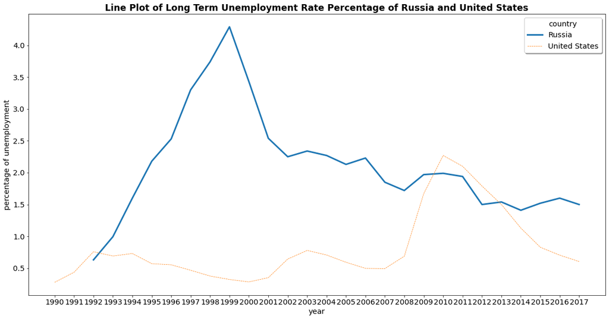

```python
plt.figure(figsize = (20, 10))
sb.lineplot(x = 'year', y='percent_unemployment', data=sample_plot, hue='country', style='country',
            size='country')
plt.title("Line Plot of Long Term Unemployment Rate Percentage of Russia and United States",
          fontdict={'fontsize': 'xx-large', 'fontweight': 'bold'})
plt.xlabel("year", fontsize='x-large')
plt.ylabel("percentage of unemployment", fontsize='x-large')
plt.xticks(fontsize='x-large')
plt.yticks(fontsize='x-large')
plt.legend(title='country', title_fontsize = 'x-large', fontsize='x-large',
          frameon=True, fancybox=True, shadow=True);
```

### Initial Observation

The result is similar to the graph in gapminder website

### Accessing the Data

- I am going to observe the melted dataset using info, descirbe, isnull()
- And I am going to observe the type of distribution by plotting a histogram and scatter plot

```python
# Observing the datatypes

df_melt.info()
```

```
<class 'pandas.core.frame.DataFrame'>
RangeIndex: 3416 entries, 0 to 3415
Data columns (total 3 columns):
 #   Column                Non-Null Count  Dtype
---  ------                --------------  -----
 0   country               3416 non-null   object
 1   year                  3416 non-null   object
 2   percent_unemployment  1472 non-null   float64
dtypes: float64(1), object(2)
memory usage: 80.2+ KB
```

```python
type(df_melt['country'][0])
```

```
str
```

```python
type(df_melt['year'][0])
```

```
str
```

```python
type(df_melt['percent_unemployment'][0])
```

```
numpy.float64
```

```python
df_melt.describe()
```

|  | percent_unemployment |
| --- | --- |
| count | 1472.000000 |
| mean | 2.020680 |
| std | 1.915901 |
| min | 0.014200 |
| 25% | 0.795000 |
| 50% | 1.475000 |
| 75% | 2.590000 |
| max | 14.000000 |

```python
df_melt.isnull().sum()
```

```
country                    0
year                       0
percent_unemployment    1944
dtype: int64
```

```python
df_melt.info()
```

```
<class 'pandas.core.frame.DataFrame'>
RangeIndex: 3416 entries, 0 to 3415
Data columns (total 3 columns):
 #   Column                Non-Null Count  Dtype
---  ------                --------------  -----
 0   country               3416 non-null   object
 1   year                  3416 non-null   object
 2   percent_unemployment  1472 non-null   float64
dtypes: float64(1), object(2)
memory usage: 80.2+ KB
```

### Drawing Histogram and Scatter Plot

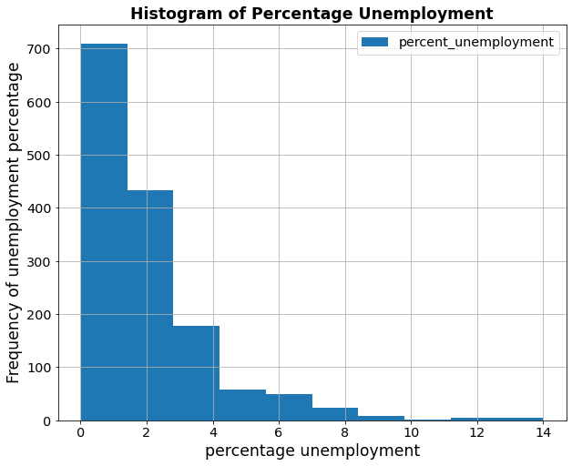

```python
plt.title("Histogram of Percentage Unemployment", fontdict={'fontsize':'xx-large', 'fontweight': 'bold'})
plt.xlabel("percentage unemployment", fontsize='xx-large')
plt.ylabel("Frequency of unemployment percentage", fontsize='xx-large')
plt.xticks(fontsize='x-large')
plt.yticks(fontsize='x-large')
df_melt['percent_unemployment'].hist(figsize=(10, 8), legend=True)
plt.legend(fontsize='x-large');
```

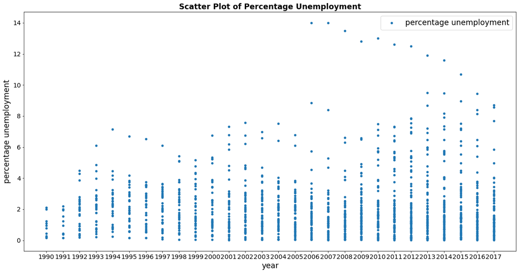

```python
df_melt.plot(x = 'year', y = 'percent_unemployment', kind='scatter',
             figsize=(20, 10),
             label="percentage unemployment",
             fontsize='x-large')
plt.title("Scatter Plot of Percentage Unemployment", fontdict={'fontsize': 'xx-large', 'fontweight': 'bold'})
plt.xlabel("year", fontsize='xx-large')
plt.ylabel("percentage unemployment", fontsize='xx-large')
plt.legend(loc='best', fontsize='xx-large');
```

### Deciding Methods to Fill NaN

- I am going to decide between filling NaN with mean, median or by interpolation
- If I choose interpolation I am going to decide about using linear or polinamial or spline interpolation
- I make a copy of the melted dataframe df_melt as df_melt_copy and work with df_melt_copy dataframe
- Once I decide about filling NaN with any of the above mentioned methods I will make final changes in df_melt dataframe

```python
df_melt['percent_unemployment'].mean()
```

```
2.020680095108696
```

```python
df_melt['percent_unemployment'].median()
```

```
1.475
```

### Reasons for not filling with Mean or Median

- The mean is more than the median
- It is clear that the distribution is right skewed, based on histogram, as well as values of both mean and mode
- Filling NaN with mean or median would mean that 56% of the NaN values will be filled with mean or median
- For better analysis I am going to fill missing values with linear interpolation

### Changing Data Type

- The year is of type str but it has to be changed to int

```python
df_melt['year'] = df_melt['year'].astype(dtype='int64')
```

```python
type(df_melt['year'][0])
```

```
numpy.int64
```

### Filling missing values

- The total number of missing values accouts for about 57% (1944 / 3416 * 100) as obtained in previous step
- The unemployment percentage is skewed to the right so there are outliers
- I am going to decide whether outliers has to be removed or not
- In the next step I plot a box plot and observe the data more clearly

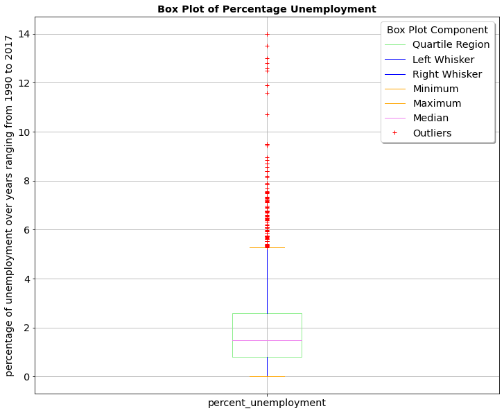

```python
color = {
    "boxes": "LightGreen",
    "whiskers": "Blue",
    "medians": "Violet",
    "caps": "Orange",
}

labels = ['Quartile Region', 'Left Whisker', 'Right Whisker', 'Minimum', 'Maximum', 'Median', 'Outliers']

df_melt['percent_unemployment'].plot(kind = 'box', figsize=(12, 10),
    grid = True,
    color=color,
    sym="r+",
    fontsize='x-large')

plt.legend(title='Box Plot Component', title_fontsize='x-large', labels=labels, fontsize='x-large',
          frameon=True, fancybox=True, shadow=True)
plt.title("Box Plot of Percentage Unemployment", fontdict={'fontsize': 'x-large', 'fontweight': 'bold'})
plt.ylabel("percentage of unemployment over years ranging from 1990 to 2017", fontsize='x-large');
```

### Notes on Box Plot Labels

- I am observing percent_unemployment alone
- I leave the x axis label just as it is
- For readability I have named the ylabel as "percentage of unemployment over the years ranging from 1990 to 2017"
- I change the colors of the box plot. I followed the procedure to change colors using pandas visualization
- Here is the [documentation](https://pandas.pydata.org/pandas-docs/stable/user_guide/visualization.html) on pandas visualization
- Using different colors for box plot components helped in legends
- I am going to adopt the same principle for rest of the box plots

### Deciding whether or not to remove the outliers

```python
# From the box plot I could see there are countable number of values as outliers from 10 percentage
# I filter unemployment percentage greater than 10
df_melt.query('percent_unemployment > 10')
```

|  | country | year | percent_unemployment |
| --- | --- | --- | --- |
| 2030 | North Macedonia | 2006 | 14.0 |
| 2152 | North Macedonia | 2007 | 14.0 |
| 2274 | North Macedonia | 2008 | 13.5 |
| 2396 | North Macedonia | 2009 | 12.8 |
| 2518 | North Macedonia | 2010 | 13.0 |
| 2640 | North Macedonia | 2011 | 12.6 |
| 2762 | North Macedonia | 2012 | 12.5 |
| 2884 | North Macedonia | 2013 | 11.9 |
| 3006 | North Macedonia | 2014 | 11.6 |
| 3128 | North Macedonia | 2015 | 10.7 |

```python
df_melt.query('percent_unemployment > 9')
```

|  | country | year | percent_unemployment |
| --- | --- | --- | --- |
| 2030 | North Macedonia | 2006 | 14.00 |
| 2152 | North Macedonia | 2007 | 14.00 |
| 2274 | North Macedonia | 2008 | 13.50 |
| 2396 | North Macedonia | 2009 | 12.80 |
| 2518 | North Macedonia | 2010 | 13.00 |
| 2640 | North Macedonia | 2011 | 12.60 |
| 2762 | North Macedonia | 2012 | 12.50 |
| 2849 | Greece | 2013 | 9.50 |
| 2884 | North Macedonia | 2013 | 11.90 |
| 2971 | Greece | 2014 | 9.48 |
| 3006 | North Macedonia | 2014 | 11.60 |
| 3128 | North Macedonia | 2015 | 10.70 |
| 3250 | North Macedonia | 2016 | 9.44 |

### Not Removing Outliers

- The outliers do not have to be removed
- The presence of outliers indicate that percentage of unemployment is diverse
- Most likely some countries have higher unemploymnet percentage than the other or same country might have different unemployment percentage for different years

### Not Removing NaN

- For some countries long term unemployment percentage for only one year is present
- If I use dropna() then analysis will be performed for countries with just one or two year unemployment percentage data
- When I had a quick glance at the data, for Zimbabwe unemployment percentage for the year 2014 alone was precent
- I am going to filter by country and just check the fitered values for Zimbabwe

```python
df_melt.query('country == "Zimbabwe"')
```

|  | country | year | percent_unemployment |
| --- | --- | --- | --- |
| 121 | Zimbabwe | 1990 | NaN |
| 243 | Zimbabwe | 1991 | NaN |
| 365 | Zimbabwe | 1992 | NaN |
| 487 | Zimbabwe | 1993 | NaN |
| 609 | Zimbabwe | 1994 | NaN |
| 731 | Zimbabwe | 1995 | NaN |
| 853 | Zimbabwe | 1996 | NaN |
| 975 | Zimbabwe | 1997 | NaN |
| 1097 | Zimbabwe | 1998 | NaN |
| 1219 | Zimbabwe | 1999 | NaN |
| 1341 | Zimbabwe | 2000 | NaN |
| 1463 | Zimbabwe | 2001 | NaN |
| 1585 | Zimbabwe | 2002 | NaN |
| 1707 | Zimbabwe | 2003 | NaN |
| 1829 | Zimbabwe | 2004 | NaN |
| 1951 | Zimbabwe | 2005 | NaN |
| 2073 | Zimbabwe | 2006 | NaN |
| 2195 | Zimbabwe | 2007 | NaN |
| 2317 | Zimbabwe | 2008 | NaN |
| 2439 | Zimbabwe | 2009 | NaN |
| 2561 | Zimbabwe | 2010 | NaN |
| 2683 | Zimbabwe | 2011 | NaN |
| 2805 | Zimbabwe | 2012 | NaN |
| 2927 | Zimbabwe | 2013 | NaN |
| 3049 | Zimbabwe | 2014 | 2.42 |
| 3171 | Zimbabwe | 2015 | NaN |
| 3293 | Zimbabwe | 2016 | NaN |
| 3415 | Zimbabwe | 2017 | NaN |

```python
# creating copies of the df_melt dataframe and deciding between linear or polinomial or spline interpolation
df_melt_linear = df_melt.copy()
```

```python
df_melt_linear.head()
```

|  | country | year | percent_unemployment |
| --- | --- | --- | --- |
| 0 | Albania | 1990 | NaN |
| 1 | Algeria | 1990 | NaN |
| 2 | Angola | 1990 | NaN |
| 3 | Argentina | 1990 | NaN |
| 4 | Armenia | 1990 | NaN |

```python
df_melt_polinomial = df_melt.copy()
```

```python
type(df_melt_polinomial['year'][0])
```

```
numpy.int64
```

```python
df_melt_polinomial.head()
```

|  | country | year | percent_unemployment |
| --- | --- | --- | --- |
| 0 | Albania | 1990 | NaN |
| 1 | Algeria | 1990 | NaN |
| 2 | Angola | 1990 | NaN |
| 3 | Argentina | 1990 | NaN |
| 4 | Armenia | 1990 | NaN |

```python
df_melt_spline = df_melt.copy()
```

```python
type(df_melt['year'][0])
```

```
numpy.int64
```

```python
type(df_melt_spline['year'][0])
```

```
numpy.int64
```

```python
df_melt_spline['year'] = df_melt_spline['year'].astype(dtype='int64')
```

```python
df_melt_spline.head()
```

|  | country | year | percent_unemployment |
| --- | --- | --- | --- |
| 0 | Albania | 1990 | NaN |
| 1 | Algeria | 1990 | NaN |
| 2 | Angola | 1990 | NaN |
| 3 | Argentina | 1990 | NaN |
| 4 | Armenia | 1990 | NaN |

```python
type(df_melt_spline['year'][0])
```

```
numpy.int64
```

```python
df_melt_linear['percent_unemployment'].interpolate(method='linear', limit_direction = "both").describe()
```

```
count    3416.000000
mean        1.901045
std         1.573176
min         0.014200
25%         0.875000
50%         1.486250
75%         2.476250
max        14.000000
Name: percent_unemployment, dtype: float64
```

```python
df_melt_polinomial['percent_unemployment'].interpolate(method='polynomial', order = 1, limit_direction='both').describe()
```

```
count    3406.000000
mean        1.904594
std         1.573839
min         0.014200
25%         0.877250
50%         1.490000
75%         2.484200
max        14.000000
Name: percent_unemployment, dtype: float64
```

```python
df_melt_spline['percent_unemployment'].interpolate(method='spline', order=1, limit_direction='both').describe()
```

```
count    3416.000000
mean        1.911787
std         1.475695
min        -0.874277
25%         1.017052
50%         1.580000
75%         2.295914
max        14.000000
Name: percent_unemployment, dtype: float64
```

```python
df_melt_spline['percent_unemployment'].interpolate(method='spline', order=1, limit_direction='both').tail(10)
```

```
3406    1.600000
3407    1.070000
3408    0.913000
3409    0.605000
3410    0.145000
3411    0.093869
3412   -0.148168
3413   -0.390204
3414   -0.632240
3415   -0.874277
Name: percent_unemployment, dtype: float64
```

```python
df_melt_spline['percent_unemployment'].interpolate(method='spline', order=2, limit_direction='both').head(10)
```

```
0    0.947038
1    0.954604
2    0.961854
3    0.968788
4    0.975405
5    1.240000
6    0.987690
7    0.993358
8    0.998709
9    1.003743
Name: percent_unemployment, dtype: float64
```

```python
df_melt_spline['percent_unemployment'].interpolate(method='spline', order=2, limit_direction='both').describe()
```

```
count    3416.000000
mean        1.992415
std         2.117184
min        -8.760937
25%         0.881750
50%         1.500000
75%         2.470282
max        19.087781
Name: percent_unemployment, dtype: float64
```

```python
df_melt_spline['percent_unemployment'].interpolate(method='spline', order=2, limit_direction='both', limit_area='outside').describe()
```

```
count    1482.000000
mean        2.009676
std         1.914691
min        -0.403136
25%         0.789000
50%         1.470000
75%         2.590000
max        14.000000
Name: percent_unemployment, dtype: float64
```

### It is necessary to visualize the dataset before finalizing an interpolation technique

- In the following steps I am going to make changes in the respective dataframes
- For linear I make the changes in the df_melt_linear dataframe
- And then I visualize the dataframe before finalizing which method I am going to adapt to fill NaN

```python
df_melt_linear['percent_unemployment'] = df_melt_linear['percent_unemployment'].interpolate(method='linear', limit_direction = "both")
```

```python
df_melt_linear.head()
```

|  | country | year | percent_unemployment |
| --- | --- | --- | --- |
| 0 | Albania | 1990 | 1.24 |
| 1 | Algeria | 1990 | 1.24 |
| 2 | Angola | 1990 | 1.24 |
| 3 | Argentina | 1990 | 1.24 |
| 4 | Armenia | 1990 | 1.24 |

```python
df_melt_polinomial['percent_unemployment'] = df_melt_polinomial['percent_unemployment'].interpolate(method='polynomial', order = 1, limit_direction='both')
```

```python
df_melt_polinomial.head(10)
```

|  | country | year | percent_unemployment |
| --- | --- | --- | --- |
| 0 | Albania | 1990 | NaN |
| 1 | Algeria | 1990 | NaN |
| 2 | Angola | 1990 | NaN |
| 3 | Argentina | 1990 | NaN |
| 4 | Armenia | 1990 | NaN |
| 5 | Australia | 1990 | 1.240000 |
| 6 | Austria | 1990 | 1.206643 |
| 7 | Azerbaijan | 1990 | 1.173286 |
| 8 | Bangladesh | 1990 | 1.139929 |
| 9 | Belarus | 1990 | 1.106571 |

```python
df_melt_polinomial.tail(10)
```

|  | country | year | percent_unemployment |
| --- | --- | --- | --- |
| 3406 | Ukraine | 2017 | 1.600 |
| 3407 | United Arab Emirates | 2017 | 1.070 |
| 3408 | United Kingdom | 2017 | 0.913 |
| 3409 | United States | 2017 | 0.605 |
| 3410 | Uruguay | 2017 | 0.145 |
| 3411 | Vanuatu | 2017 | NaN |
| 3412 | Venezuela | 2017 | NaN |
| 3413 | Vietnam | 2017 | NaN |
| 3414 | Yemen | 2017 | NaN |
| 3415 | Zimbabwe | 2017 | NaN |

```python
df_melt_polinomial.sample(10)
```

|  | country | year | percent_unemployment |
| --- | --- | --- | --- |
| 396 | Dominican Republic | 1993 | 2.527500 |
| 525 | Finland | 1994 | 2.954000 |
| 1452 | Turkey | 2001 | 1.070000 |
| 3412 | Venezuela | 2017 | NaN |
| 739 | Azerbaijan | 1996 | 1.555000 |
| 2593 | Ecuador | 2011 | 0.285000 |
| 22 | Colombia | 1990 | 0.646143 |
| 3119 | Mongolia | 2015 | 1.470000 |
| 2168 | Senegal | 2007 | 3.467143 |
| 2858 | Italy | 2013 | 3.640000 |

```python
df_melt_polinomial.query('country == "Zimbabwe"')
```

|  | country | year | percent_unemployment |
| --- | --- | --- | --- |
| 121 | Zimbabwe | 1990 | 1.109000 |
| 243 | Zimbabwe | 1991 | 1.548000 |
| 365 | Zimbabwe | 1992 | 1.734500 |
| 487 | Zimbabwe | 1993 | 1.530500 |
| 609 | Zimbabwe | 1994 | 1.320500 |
| 731 | Zimbabwe | 1995 | 1.165500 |
| 853 | Zimbabwe | 1996 | 1.202000 |
| 975 | Zimbabwe | 1997 | 1.124000 |
| 1097 | Zimbabwe | 1998 | 0.923500 |
| 1219 | Zimbabwe | 1999 | 0.781500 |
| 1341 | Zimbabwe | 2000 | 0.762500 |
| 1463 | Zimbabwe | 2001 | 0.760500 |
| 1585 | Zimbabwe | 2002 | 0.847000 |
| 1707 | Zimbabwe | 2003 | 1.343600 |
| 1829 | Zimbabwe | 2004 | 1.116800 |
| 1951 | Zimbabwe | 2005 | 1.275714 |
| 2073 | Zimbabwe | 2006 | 4.290000 |
| 2195 | Zimbabwe | 2007 | 3.583750 |
| 2317 | Zimbabwe | 2008 | 3.859500 |
| 2439 | Zimbabwe | 2009 | 4.428750 |
| 2561 | Zimbabwe | 2010 | 4.171000 |
| 2683 | Zimbabwe | 2011 | 3.611000 |
| 2805 | Zimbabwe | 2012 | 3.758000 |
| 2927 | Zimbabwe | 2013 | 3.895667 |
| 3049 | Zimbabwe | 2014 | 2.420000 |
| 3171 | Zimbabwe | 2015 | 2.781000 |
| 3293 | Zimbabwe | 2016 | 0.701333 |
| 3415 | Zimbabwe | 2017 | NaN |

```python
df_melt_polinomial.query('country == "Albania"')
```

|  | country | year | percent_unemployment |
| --- | --- | --- | --- |
| 0 | Albania | 1990 | NaN |
| 122 | Albania | 1991 | 1.247500 |
| 244 | Albania | 1992 | 1.733333 |
| 366 | Albania | 1993 | 1.897083 |
| 488 | Albania | 1994 | 1.670417 |
| 610 | Albania | 1995 | 1.418750 |
| 732 | Albania | 1996 | 1.264583 |
| 854 | Albania | 1997 | 1.310000 |
| 976 | Albania | 1998 | 1.233333 |
| 1098 | Albania | 1999 | 1.014583 |
| 1220 | Albania | 2000 | 0.857917 |
| 1342 | Albania | 2001 | 0.842083 |
| 1464 | Albania | 2002 | 0.828750 |
| 1586 | Albania | 2003 | 0.880833 |
| 1708 | Albania | 2004 | 1.437700 |
| 1830 | Albania | 2005 | 1.185100 |
| 1952 | Albania | 2006 | 1.234286 |
| 2074 | Albania | 2007 | 5.290000 |
| 2196 | Albania | 2008 | 4.500000 |
| 2318 | Albania | 2009 | 4.910000 |
| 2440 | Albania | 2010 | 5.670000 |
| 2562 | Albania | 2011 | 5.280000 |
| 2684 | Albania | 2012 | 5.300000 |
| 2806 | Albania | 2013 | 5.530000 |
| 2928 | Albania | 2014 | 5.760000 |
| 3050 | Albania | 2015 | 6.090000 |
| 3172 | Albania | 2016 | 3.304800 |
| 3294 | Albania | 2017 | 0.811000 |

## Observations From Using Linear & Polynomial Interpolation

- The linear method will fill all the NaN once I specify limit_direction = 'both'
- The same is not the case with polynomial interpolation
- Since the NaN is more than 50% linear interpolation will not result in a better approximation
- I am going to try spline method and interpolate

## Observations From Using Spline Method

```python
df_melt_spline['percent_unemployment'].isnull().sum()
```

```
1944
```

```python
df_melt_spline['percent_unemployment'] = df_melt_spline['percent_unemployment'].interpolate(method='spline', order=1,  limit_direction="both", limit_area='inside' )
```

```python
df_melt_spline.head(10)
```

|  | country | year | percent_unemployment |
| --- | --- | --- | --- |
| 0 | Albania | 1990 | NaN |
| 1 | Algeria | 1990 | NaN |
| 2 | Angola | 1990 | NaN |
| 3 | Argentina | 1990 | NaN |
| 4 | Armenia | 1990 | NaN |
| 5 | Australia | 1990 | 1.240000 |
| 6 | Austria | 1990 | 0.880416 |
| 7 | Azerbaijan | 1990 | 0.881382 |
| 8 | Bangladesh | 1990 | 0.882349 |
| 9 | Belarus | 1990 | 0.883315 |

```python
df_melt_spline.tail(10)
```

|  | country | year | percent_unemployment |
| --- | --- | --- | --- |
| 3406 | Ukraine | 2017 | 1.600 |
| 3407 | United Arab Emirates | 2017 | 1.070 |
| 3408 | United Kingdom | 2017 | 0.913 |
| 3409 | United States | 2017 | 0.605 |
| 3410 | Uruguay | 2017 | 0.145 |
| 3411 | Vanuatu | 2017 | NaN |
| 3412 | Venezuela | 2017 | NaN |
| 3413 | Vietnam | 2017 | NaN |
| 3414 | Yemen | 2017 | NaN |
| 3415 | Zimbabwe | 2017 | NaN |

```python
df_melt_spline.query('country == "Zimbabwe"')
```

|  | country | year | percent_unemployment |
| --- | --- | --- | --- |
| 121 | Zimbabwe | 1990 | 0.991559 |
| 243 | Zimbabwe | 1991 | 1.292039 |
| 365 | Zimbabwe | 1992 | 1.980912 |
| 487 | Zimbabwe | 1993 | 2.000270 |
| 609 | Zimbabwe | 1994 | 1.839142 |
| 731 | Zimbabwe | 1995 | 1.672210 |
| 853 | Zimbabwe | 1996 | 1.496371 |
| 975 | Zimbabwe | 1997 | 1.375782 |
| 1097 | Zimbabwe | 1998 | 1.341262 |
| 1219 | Zimbabwe | 1999 | 0.926191 |
| 1341 | Zimbabwe | 2000 | 0.724857 |
| 1463 | Zimbabwe | 2001 | 0.755211 |
| 1585 | Zimbabwe | 2002 | 1.155436 |
| 1707 | Zimbabwe | 2003 | 1.238857 |
| 1829 | Zimbabwe | 2004 | 1.248091 |
| 1951 | Zimbabwe | 2005 | 0.959781 |
| 2073 | Zimbabwe | 2006 | 2.233150 |
| 2195 | Zimbabwe | 2007 | 3.517846 |
| 2317 | Zimbabwe | 2008 | 2.381087 |
| 2439 | Zimbabwe | 2009 | 4.357360 |
| 2561 | Zimbabwe | 2010 | 1.675963 |
| 2683 | Zimbabwe | 2011 | 2.882836 |
| 2805 | Zimbabwe | 2012 | 2.770101 |
| 2927 | Zimbabwe | 2013 | 3.691273 |
| 3049 | Zimbabwe | 2014 | 2.420000 |
| 3171 | Zimbabwe | 2015 | 2.144443 |
| 3293 | Zimbabwe | 2016 | 1.155375 |
| 3415 | Zimbabwe | 2017 | NaN |

```python
df_melt_linear.describe()
```

|  | year | percent_unemployment |
| --- | --- | --- |
| count | 3416.00000 | 3416.000000 |
| mean | 2003.50000 | 1.901045 |
| std | 8.07893 | 1.573176 |
| min | 1990.00000 | 0.014200 |
| 25% | 1996.75000 | 0.875000 |
| 50% | 2003.50000 | 1.486250 |
| 75% | 2010.25000 | 2.476250 |
| max | 2017.00000 | 14.000000 |

```python
df_melt_linear['percent_unemployment'].isnull().sum()
```

```
0
```

```python
df_melt_polinomial['percent_unemployment'].describe()
```

```
count    3406.000000
mean        1.904594
std         1.573839
min         0.014200
25%         0.877250
50%         1.490000
75%         2.484200
max        14.000000
Name: percent_unemployment, dtype: float64
```

```python
df_melt_polinomial['percent_unemployment'].isnull().sum()
```

```
10
```

```python
df_melt_spline['percent_unemployment'].isnull().sum()
```

```
10
```

```python
df_melt_spline['percent_unemployment'].describe()
```

```
count    3406.000000
mean        1.916686
std         1.474625
min        -0.079501
25%         1.020000
50%         1.590000
75%         2.300000
max        14.000000
Name: percent_unemployment, dtype: float64
```

```python
df_melt_spline['percent_unemployment'].min()
```

```
-0.07950096402200127
```

```python
df_melt_spline.query('percent_unemployment == percent_unemployment.min()')
```

|  | country | year | percent_unemployment |
| --- | --- | --- | --- |
| 1166 | Moldova | 1999 | -0.079501 |

```python
df_melt_spline['percent_unemployment'].isnull().sum()
```

```
10
```

```python
df_melt_spline.query('percent_unemployment < 0.0')
```

|  | country | year | percent_unemployment |
| --- | --- | --- | --- |
| 1166 | Moldova | 1999 | -0.079501 |

```python
df_melt_linear['percent_unemployment'].median()
```

```
1.4862499999999998
```

```python
df_melt_polinomial['percent_unemployment'].median()
```

```
1.49
```

```python
df_melt_spline['percent_unemployment'].median()
```

```
1.59
```

### A blog post on counting [negative values](https://stackoverflow.com/questions/36155942/need-count-of-negative-values-in-a-dataframe)

```python
df_melt_spline['percent_unemployment'].lt(0).sum().sum()
```

```
1
```

```python
df_melt_spline.query('country == "Zimbabwe"')
```

|  | country | year | percent_unemployment |
| --- | --- | --- | --- |
| 121 | Zimbabwe | 1990 | 0.991559 |
| 243 | Zimbabwe | 1991 | 1.292039 |
| 365 | Zimbabwe | 1992 | 1.980912 |
| 487 | Zimbabwe | 1993 | 2.000270 |
| 609 | Zimbabwe | 1994 | 1.839142 |
| 731 | Zimbabwe | 1995 | 1.672210 |
| 853 | Zimbabwe | 1996 | 1.496371 |
| 975 | Zimbabwe | 1997 | 1.375782 |
| 1097 | Zimbabwe | 1998 | 1.341262 |
| 1219 | Zimbabwe | 1999 | 0.926191 |
| 1341 | Zimbabwe | 2000 | 0.724857 |
| 1463 | Zimbabwe | 2001 | 0.755211 |
| 1585 | Zimbabwe | 2002 | 1.155436 |
| 1707 | Zimbabwe | 2003 | 1.238857 |
| 1829 | Zimbabwe | 2004 | 1.248091 |
| 1951 | Zimbabwe | 2005 | 0.959781 |
| 2073 | Zimbabwe | 2006 | 2.233150 |
| 2195 | Zimbabwe | 2007 | 3.517846 |
| 2317 | Zimbabwe | 2008 | 2.381087 |
| 2439 | Zimbabwe | 2009 | 4.357360 |
| 2561 | Zimbabwe | 2010 | 1.675963 |
| 2683 | Zimbabwe | 2011 | 2.882836 |
| 2805 | Zimbabwe | 2012 | 2.770101 |
| 2927 | Zimbabwe | 2013 | 3.691273 |
| 3049 | Zimbabwe | 2014 | 2.420000 |
| 3171 | Zimbabwe | 2015 | 2.144443 |
| 3293 | Zimbabwe | 2016 | 1.155375 |
| 3415 | Zimbabwe | 2017 | NaN |

```python
df_melt_spline['percent_unemployment'].lt(0).sum().sum()
```

```
1
```

```python
df_melt_spline.query('percent_unemployment < 0.')
```

|  | country | year | percent_unemployment |
| --- | --- | --- | --- |
| 1166 | Moldova | 1999 | -0.079501 |

## Replacing negative values with mean

```python
df_melt_spline['percent_unemployment'].mean()
```

```
1.9166856645604438
```

```python
df_melt_spline[df_melt_spline['percent_unemployment'] < 0] = df_melt_spline['percent_unemployment'].mean()
```

```python
df_melt_spline['percent_unemployment'].describe()
```

```
count    3406.000000
mean        1.917272
std         1.474228
min         0.014200
25%         1.020000
50%         1.590208
75%         2.300000
max        14.000000
Name: percent_unemployment, dtype: float64
```

```python
# making sure that no changes are made in the original melted dataframe
df_melt['percent_unemployment'].isnull().sum()
```

```
1944
```

```python
df_melt.query('country == "Zimbabwe"')
```

|  | country | year | percent_unemployment |
| --- | --- | --- | --- |
| 121 | Zimbabwe | 1990 | NaN |
| 243 | Zimbabwe | 1991 | NaN |
| 365 | Zimbabwe | 1992 | NaN |
| 487 | Zimbabwe | 1993 | NaN |
| 609 | Zimbabwe | 1994 | NaN |
| 731 | Zimbabwe | 1995 | NaN |
| 853 | Zimbabwe | 1996 | NaN |
| 975 | Zimbabwe | 1997 | NaN |
| 1097 | Zimbabwe | 1998 | NaN |
| 1219 | Zimbabwe | 1999 | NaN |
| 1341 | Zimbabwe | 2000 | NaN |
| 1463 | Zimbabwe | 2001 | NaN |
| 1585 | Zimbabwe | 2002 | NaN |
| 1707 | Zimbabwe | 2003 | NaN |
| 1829 | Zimbabwe | 2004 | NaN |
| 1951 | Zimbabwe | 2005 | NaN |
| 2073 | Zimbabwe | 2006 | NaN |
| 2195 | Zimbabwe | 2007 | NaN |
| 2317 | Zimbabwe | 2008 | NaN |
| 2439 | Zimbabwe | 2009 | NaN |
| 2561 | Zimbabwe | 2010 | NaN |
| 2683 | Zimbabwe | 2011 | NaN |
| 2805 | Zimbabwe | 2012 | NaN |
| 2927 | Zimbabwe | 2013 | NaN |
| 3049 | Zimbabwe | 2014 | 2.42 |
| 3171 | Zimbabwe | 2015 | NaN |
| 3293 | Zimbabwe | 2016 | NaN |
| 3415 | Zimbabwe | 2017 | NaN |